# US Cities - National Level Trends

11/30/2020

Visualize national level trends & model relationships between breast cancer mortality and preventive screening methods (mammography usage) across U.S. cities

#### Load Data

```r
dat <- read_excel('./data/city_total_data.xlsx')
```

```
## * `` -> ...1
```

## Part I: Regression Analysis between Mammogram Usage & Breast Cancer Mortality

### A. Exploratory Data Analysis for Regression Model

The outcome (breast cancer mortality rate) and primary covariates (mammogram usage rate) are mostly normally distributed. Breast cancer mortality does have some extreme values in the right tail, which could lead to biased error estimates.

Because the outcome is a rate, a Poisson regression model was initially considered. However, the distribution of outcome values does not follow the characteristic Poisson curve for small $\lambda$ values for which a Poisson regression model would be necessary for unbiased estimation. At larger Poisson $\lambda$ values, Poisson distributions of rates converge to normal distributions, and so breast cancer mortality rates can be approximated with a normal distribution. Thus, a multiple linear regression model is presumed to be a valid modeling approach for the outcome.

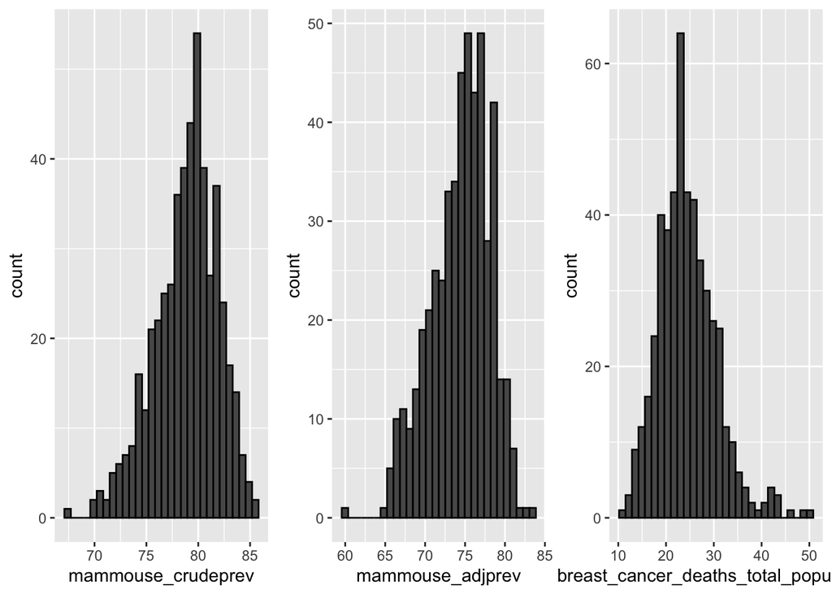

```r
p1 <- dat %>% ggplot() +
        geom_histogram(aes(mammouse_crudeprev), col = 1)

p2 <- dat %>% ggplot() +
        geom_histogram(aes(mammouse_adjprev), col = 1)

p3 <- dat %>% ggplot() +
        geom_histogram(aes(breast_cancer_deaths_total_population), col = 1)


grid.arrange(p1, p2, p3, nrow =1 )
```

The loess curves indicate that there is an inverse relationship between mammography screenings and breast cancer mortality for both the crude & age adjusted mammography usage rates. Because the age adjusted mammography usage rate is better representative of the city population, we will be using this for the analysis moving forward.

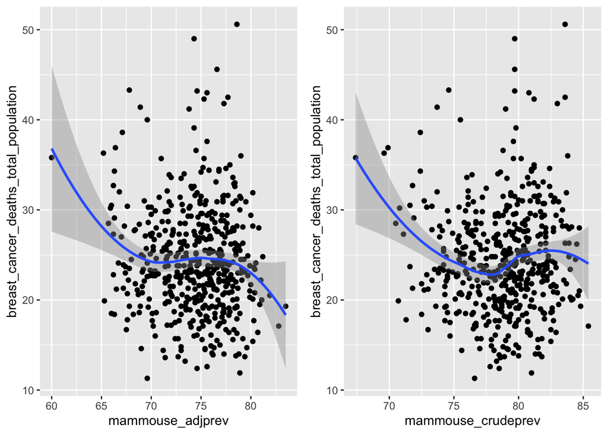

```r
p1 <- dat %>% ggplot(aes(mammouse_adjprev, breast_cancer_deaths_total_population)) +
        geom_point() +
        geom_smooth()

p2 <- dat %>% ggplot(aes(mammouse_crudeprev, breast_cancer_deaths_total_population)) +
        geom_point() +
        geom_smooth()


grid.arrange(p1, p2, nrow =1 )
```

There seems to be a slight positive relationship between the raw number of mammography sites in a city and mammography usage, particularly at the lower number of sites (<10).

However, after accounting for the varying population sizes in a city, a stronger positive relationship seems to be present when looking at the correlation between sites per 100,000 people in the population and the age adjusted mammography usage rate.

```r
dat <- dat %>% mutate(sites_per_100K = number_sites/(population2010/100000))
```

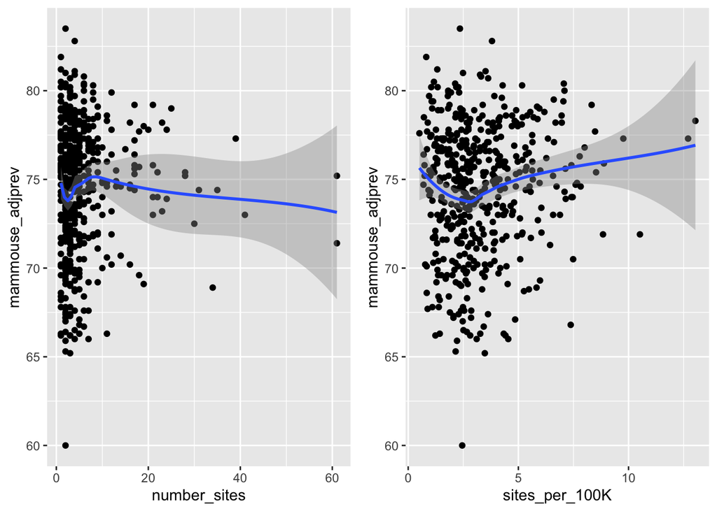

```r
p1 <- dat %>% ggplot(aes(number_sites, mammouse_adjprev)) +
        geom_point() +
        geom_smooth()

p2  <-   dat %>%
        ggplot(aes(sites_per_100K, mammouse_adjprev)) +
        geom_point() +
        geom_smooth()

grid.arrange(p1, p2, nrow =1 )
```

Assess Potential Multicollinearity & Associations with Breast Cancer Mortality (outcome)

```r
library(corrplot)
# chdb factors
vars <- c(c("breast_cancer_deaths_total_population",

            "air_pollution_particulate_matter_total_population",
            "housing_with_potential_lead_risk_total_population",
            "walkability_total_population",
            "limited_access_to_healthy_foods_total_population",

            "binge_drinking_total_population",
            "diabetes_total_population",
            "obesity_total_population",
            "smoking_total_population",

            "unemployment_annual_neighborhood_level_total_population",
            "income_inequality_total_population",
            "neighborhood_racial_ethnic_segregation_total_population",
            "racial_ethnic_diversity_total_population",

             "number_sites",
             "sites_per_100K"
            ),
          c("mammouse_adjprev", "corew_adjprev", "paptest_adjprev"))
covars <- dat %>% select(vars) %>% drop_na()
```

```
## Note: Using an external vector in selections is ambiguous.
## ℹ Use `all_of(vars)` instead of `vars` to silence this message.
## ℹ See <https://tidyselect.r-lib.org/reference/faq-external-vector.html>.
```

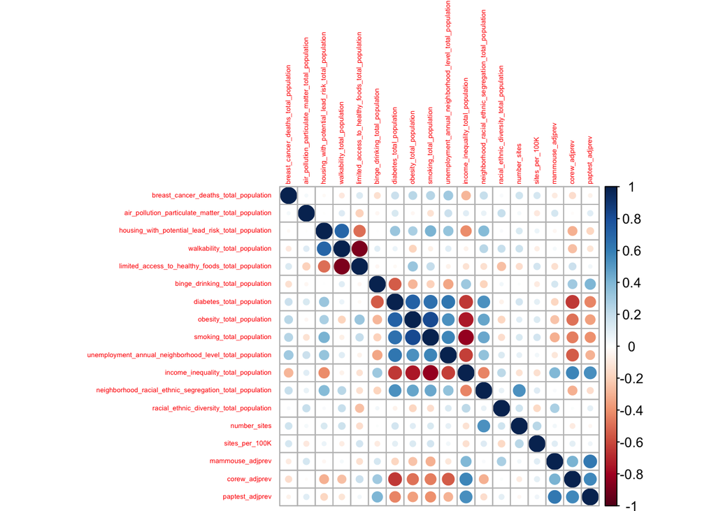

```r
corrplot(cor(covars), tl.cex = 0.4)
```

### B. Linear Regression Model

Initial Model fit examining relationship between mammography usage & breast cancer deaths

```r
red_mod <- lm(breast_cancer_deaths_total_population ~ mammouse_adjprev, data = dat)
summary(red_mod)
```

```
##
## Call:
## lm(formula = breast_cancer_deaths_total_population ~ mammouse_adjprev,
##     data = dat)
##
## Residuals:
##      Min       1Q   Median       3Q      Max
## -13.8562  -4.1228  -0.7432   3.4915  26.7909
##
## Coefficients:
##                  Estimate Std. Error t value Pr(>|t|)
## (Intercept)      35.57337    5.52442   6.439 2.84e-10 ***
## mammouse_adjprev -0.14967    0.07416  -2.018   0.0441 *
## ---
## Signif. codes:  0 '***' 0.001 '**' 0.01 '*' 0.05 '.' 0.1 ' ' 1
##
## Residual standard error: 6.016 on 495 degrees of freedom
##   (3 observations deleted due to missingness)
## Multiple R-squared:  0.008161,   Adjusted R-squared:  0.006157
## F-statistic: 4.073 on 1 and 495 DF,  p-value: 0.04412
```

Expanded model accounting for racial diversity, racial segregation, and unemployment factors.

The F-Test comparing the two model fits indicate that the full model is needed to explain the variance of the outcome (p<0.05), and the AIC score of the full model is lower than the reduced model (full model AIC 3146.121, reduced model AIC 3198.022), indicating that the full model better fits the observed data.

Categorize unemployment levels into above & below national average (median unemployment level is 5.9.

```r
dat <- dat %>% mutate(high_unemployment = ifelse(unemployment_annual_neighborhood_level_total_population < 5.9,
                                                  0, 1))
```

```r
full_mod <- lm(breast_cancer_deaths_total_population ~ mammouse_adjprev +
               racial_ethnic_diversity_total_population +
               I(racial_ethnic_diversity_total_population**2) +
               neighborhood_racial_ethnic_segregation_total_population +
               #unemployment_annual_neighborhood_level_total_population,
               high_unemployment,  # categorical var has slightly better fit than continuous & is easier to interpret
          data = dat)
summary(full_mod)
```

```
##
## Call:
## lm(formula = breast_cancer_deaths_total_population ~ mammouse_adjprev +
##     racial_ethnic_diversity_total_population + I(racial_ethnic_diversity_total_population^2) +
##     neighborhood_racial_ethnic_segregation_total_population +
##     high_unemployment, data = dat)
##
## Residuals:
##      Min       1Q   Median       3Q      Max
## -15.9068  -3.8716  -0.4676   3.0575  24.2158
##
## Coefficients:
##                                                          Estimate Std. Error
## (Intercept)                                             23.857524   5.828762
## mammouse_adjprev                                        -0.177108   0.073258
## racial_ethnic_diversity_total_population                 0.383278   0.105811
## I(racial_ethnic_diversity_total_population^2)           -0.003111   0.000874
## neighborhood_racial_ethnic_segregation_total_population  0.093826   0.038250
## high_unemployment                                        2.928212   0.538510
##                                                         t value Pr(>|t|)
## (Intercept)                                               4.093 4.98e-05 ***
## mammouse_adjprev                                         -2.418 0.015986 *
## racial_ethnic_diversity_total_population                  3.622 0.000322 ***
## I(racial_ethnic_diversity_total_population^2)            -3.559 0.000408 ***
## neighborhood_racial_ethnic_segregation_total_population   2.453 0.014515 *
## high_unemployment                                         5.438 8.53e-08 ***
## ---
## Signif. codes:  0 '***' 0.001 '**' 0.01 '*' 0.05 '.' 0.1 ' ' 1
##
## Residual standard error: 5.687 on 491 degrees of freedom
##   (3 observations deleted due to missingness)
## Multiple R-squared:  0.1208, Adjusted R-squared:  0.1118
## F-statistic: 13.49 on 5 and 491 DF,  p-value: 2.414e-12
```

```r
anova(red_mod, full_mod)
```

```
## Analysis of Variance Table
##
## Model 1: breast_cancer_deaths_total_population ~ mammouse_adjprev
## Model 2: breast_cancer_deaths_total_population ~ mammouse_adjprev + racial_ethnic_diversity_total_population +
##     I(racial_ethnic_diversity_total_population^2) + neighborhood_racial_ethnic_segregation_total_population +
##     high_unemployment
##   Res.Df   RSS Df Sum of Sq      F    Pr(>F)
## 1    495 17913
## 2    491 15879  4      2034 15.723 4.074e-12 ***
## ---
## Signif. codes:  0 '***' 0.001 '**' 0.01 '*' 0.05 '.' 0.1 ' ' 1
```

```r
AIC(full_mod)
```

```
## [1] 3146.121
```

```r
AIC(red_mod)
```

```
## [1] 3198.022
```

#### Consider Health Factors

Health factors such as smoking, binge drinking, and diabetes are not statistically significant predictors (p>0.05) either in complete model or through forward selection method where each variable is added individually.

```r
h1 <- lm(breast_cancer_deaths_total_population ~ mammouse_adjprev +
               racial_ethnic_diversity_total_population +
               I(racial_ethnic_diversity_total_population**2) +
               neighborhood_racial_ethnic_segregation_total_population +
               high_unemployment +
               diabetes_total_population +
               binge_drinking_total_population +
               smoking_total_population,
          data = dat)
summary(h1)
```

```
##
## Call:
## lm(formula = breast_cancer_deaths_total_population ~ mammouse_adjprev +
##     racial_ethnic_diversity_total_population + I(racial_ethnic_diversity_total_population^2) +
##     neighborhood_racial_ethnic_segregation_total_population +
##     high_unemployment + diabetes_total_population + binge_drinking_total_population +
##     smoking_total_population, data = dat)
##
## Residuals:
##      Min       1Q   Median       3Q      Max
## -15.4507  -3.8071  -0.5026   3.1404  24.1818
##
## Coefficients:
##                                                           Estimate Std. Error
## (Intercept)                                             25.4274770  6.9740385
## mammouse_adjprev                                        -0.1533665  0.0782680
## racial_ethnic_diversity_total_population                 0.3465603  0.1116942
## I(racial_ethnic_diversity_total_population^2)           -0.0027933  0.0009259
## neighborhood_racial_ethnic_segregation_total_population  0.0936173  0.0451966
## high_unemployment                                        2.8137283  0.6067288
## diabetes_total_population                               -0.1573562  0.1781245
## binge_drinking_total_population                         -0.1220250  0.1181931
## smoking_total_population                                 0.0869593  0.0954872
##                                                         t value Pr(>|t|)
## (Intercept)                                               3.646 0.000295 ***
## mammouse_adjprev                                         -1.960 0.050623 .
## racial_ethnic_diversity_total_population                  3.103 0.002028 **
## I(racial_ethnic_diversity_total_population^2)            -3.017 0.002688 **
## neighborhood_racial_ethnic_segregation_total_population   2.071 0.038852 *
## high_unemployment                                         4.638 4.53e-06 ***
## diabetes_total_population                                -0.883 0.377452
## binge_drinking_total_population                          -1.032 0.302387
## smoking_total_population                                  0.911 0.362908
## ---
## Signif. codes:  0 '***' 0.001 '**' 0.01 '*' 0.05 '.' 0.1 ' ' 1
##
## Residual standard error: 5.695 on 488 degrees of freedom
##   (3 observations deleted due to missingness)
## Multiple R-squared:  0.1235, Adjusted R-squared:  0.1092
## F-statistic: 8.597 on 8 and 488 DF,  p-value: 5.45e-11
```

#### Assess Potential Effect Modification

Interaction term is not strictly significant at the alpha = 0.05 level.

```r
em_mod <- lm(breast_cancer_deaths_total_population ~ mammouse_adjprev +
               racial_ethnic_diversity_total_population +
               I(racial_ethnic_diversity_total_population**2) +
               neighborhood_racial_ethnic_segregation_total_population +
               unemployment_annual_neighborhood_level_total_population +
               unemployment_annual_neighborhood_level_total_population*mammouse_adjprev,
          data = dat)
summary(em_mod)
```

```
##
## Call:
## lm(formula = breast_cancer_deaths_total_population ~ mammouse_adjprev +
##     racial_ethnic_diversity_total_population + I(racial_ethnic_diversity_total_population^2) +
##     neighborhood_racial_ethnic_segregation_total_population +
##     unemployment_annual_neighborhood_level_total_population +
##     unemployment_annual_neighborhood_level_total_population *
##         mammouse_adjprev, data = dat)
##
## Residuals:
##      Min       1Q   Median       3Q      Max
## -14.4334  -3.8223  -0.5548   3.2625  24.8918
##
## Coefficients:
##                                                                            Estimate
## (Intercept)                                                              48.4900022
## mammouse_adjprev                                                         -0.5333081
## racial_ethnic_diversity_total_population                                  0.3759342
## I(racial_ethnic_diversity_total_population^2)                            -0.0030263
## neighborhood_racial_ethnic_segregation_total_population                   0.0752058
## unemployment_annual_neighborhood_level_total_population                  -3.7183260
## mammouse_adjprev:unemployment_annual_neighborhood_level_total_population  0.0577761
##                                                                          Std. Error
## (Intercept)                                                              15.4137464
## mammouse_adjprev                                                          0.2066867
## racial_ethnic_diversity_total_population                                  0.1061184
## I(racial_ethnic_diversity_total_population^2)                             0.0008759
## neighborhood_racial_ethnic_segregation_total_population                   0.0392829
## unemployment_annual_neighborhood_level_total_population                   2.2736023
## mammouse_adjprev:unemployment_annual_neighborhood_level_total_population  0.0305599
##                                                                          t value
## (Intercept)                                                                3.146
## mammouse_adjprev                                                          -2.580
## racial_ethnic_diversity_total_population                                   3.543
## I(racial_ethnic_diversity_total_population^2)                             -3.455
## neighborhood_racial_ethnic_segregation_total_population                    1.914
## unemployment_annual_neighborhood_level_total_population                   -1.635
## mammouse_adjprev:unemployment_annual_neighborhood_level_total_population   1.891
##                                                                          Pr(>|t|)
## (Intercept)                                                              0.001756
## mammouse_adjprev                                                         0.010162
## racial_ethnic_diversity_total_population                                 0.000434
## I(racial_ethnic_diversity_total_population^2)                            0.000598
## neighborhood_racial_ethnic_segregation_total_population                  0.056143
## unemployment_annual_neighborhood_level_total_population                  0.102600
## mammouse_adjprev:unemployment_annual_neighborhood_level_total_population 0.059270
##
## (Intercept)                                                              **
## mammouse_adjprev                                                         *
## racial_ethnic_diversity_total_population                                 ***
## I(racial_ethnic_diversity_total_population^2)                            ***
## neighborhood_racial_ethnic_segregation_total_population                  .
## unemployment_annual_neighborhood_level_total_population
## mammouse_adjprev:unemployment_annual_neighborhood_level_total_population .
## ---
## Signif. codes:  0 '***' 0.001 '**' 0.01 '*' 0.05 '.' 0.1 ' ' 1
##
## Residual standard error: 5.689 on 490 degrees of freedom
##   (3 observations deleted due to missingness)
## Multiple R-squared:  0.1219, Adjusted R-squared:  0.1112
## F-statistic: 11.34 on 6 and 490 DF,  p-value: 7.025e-12
```

Effect modification is not supported by data in either the continuous or categorical model.

```r
em_mod2 <- lm(breast_cancer_deaths_total_population ~ mammouse_adjprev +
               racial_ethnic_diversity_total_population +
               I(racial_ethnic_diversity_total_population**2) +
               neighborhood_racial_ethnic_segregation_total_population +
               high_unemployment +
               high_unemployment*mammouse_adjprev,
          data = dat)
summary(em_mod2)
```

```
##
## Call:
## lm(formula = breast_cancer_deaths_total_population ~ mammouse_adjprev +
##     racial_ethnic_diversity_total_population + I(racial_ethnic_diversity_total_population^2) +
##     neighborhood_racial_ethnic_segregation_total_population +
##     high_unemployment + high_unemployment * mammouse_adjprev,
##     data = dat)
##
## Residuals:
##      Min       1Q   Median       3Q      Max
## -15.4448  -3.7598  -0.4031   3.2499  23.7869
##
## Coefficients:
##                                                           Estimate Std. Error
## (Intercept)                                              3.184e+01  7.826e+00
## mammouse_adjprev                                        -2.846e-01  1.016e-01
## racial_ethnic_diversity_total_population                 3.890e-01  1.057e-01
## I(racial_ethnic_diversity_total_population^2)           -3.168e-03  8.737e-04
## neighborhood_racial_ethnic_segregation_total_population  8.431e-02  3.870e-02
## high_unemployment                                       -1.318e+01  1.056e+01
## mammouse_adjprev:high_unemployment                       2.170e-01  1.422e-01
##                                                         t value Pr(>|t|)
## (Intercept)                                               4.069 5.51e-05 ***
## mammouse_adjprev                                         -2.803 0.005269 **
## racial_ethnic_diversity_total_population                  3.679 0.000260 ***
## I(racial_ethnic_diversity_total_population^2)            -3.626 0.000318 ***
## neighborhood_racial_ethnic_segregation_total_population   2.178 0.029855 *
## high_unemployment                                        -1.247 0.212896
## mammouse_adjprev:high_unemployment                        1.526 0.127542
## ---
## Signif. codes:  0 '***' 0.001 '**' 0.01 '*' 0.05 '.' 0.1 ' ' 1
##
## Residual standard error: 5.679 on 490 degrees of freedom
##   (3 observations deleted due to missingness)
## Multiple R-squared:  0.1249, Adjusted R-squared:  0.1142
## F-statistic: 11.66 on 6 and 490 DF,  p-value: 3.161e-12
```

### C. Model Diagnostics

The residuals are mostly randomly scattered with a few outliers where the observed breast cancer deaths are much greater than the predicted values from the model. This is also seen in the qq plot where the residuals appear right skewed. This departure from normality does limit the accuracy of the standard errors of the beta coefficients, and may result in biased confidence interval calculations. However, the beta coefficients themselves are unbiased.

The leverage plot also shows that there are some potentially influential points in the dataset, which might be disproportionately driving the estimated coefficients. However, because we are relying on publicly available data, and do not have cause to believe there was measurement error or aberrant behavior explaining the influential points, we will use all data points to estimate the beta coefficients of the multiple linear regression model.

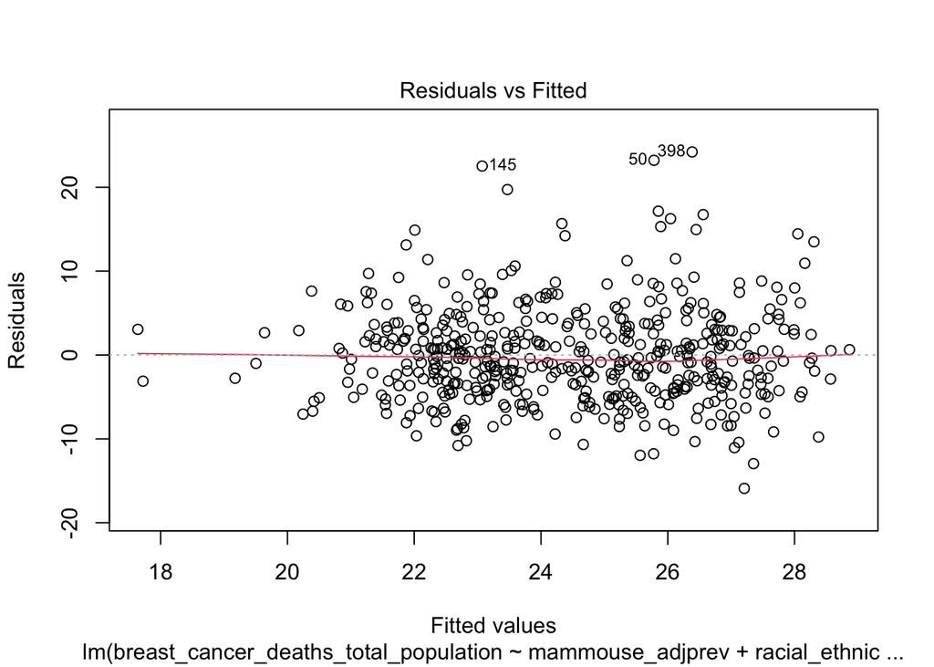

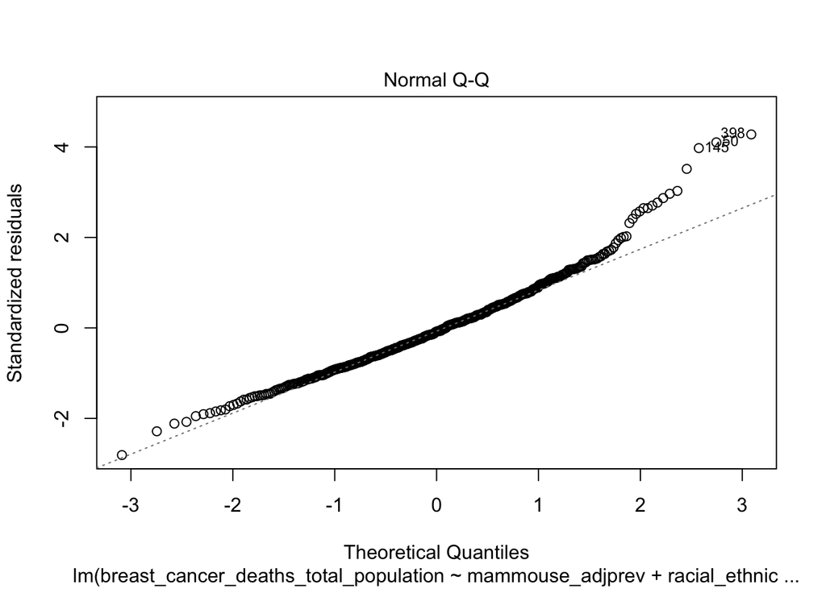

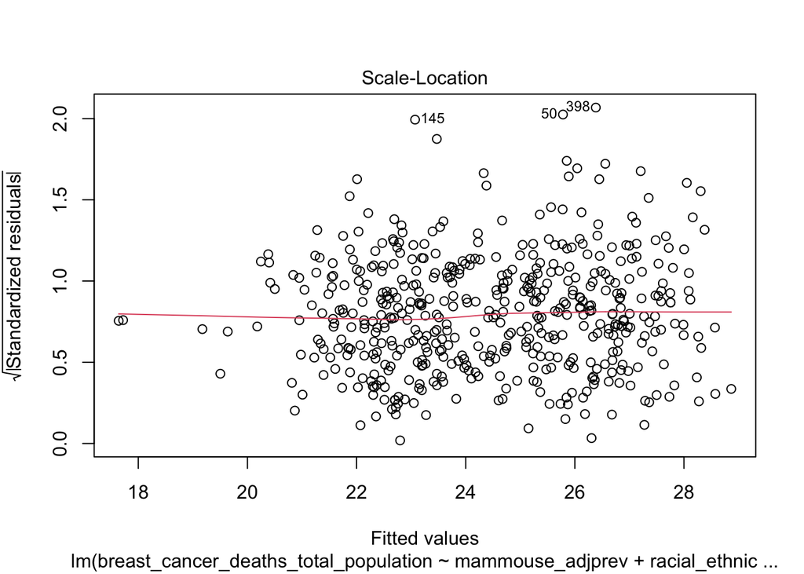

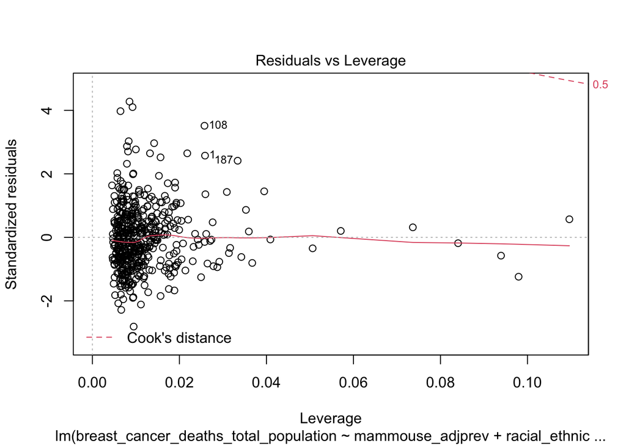

```r
plot(full_mod)
```

#### Robust Sandwich Errors for Coefficient Estimates

Because the residual plot depicts a violation of homoscedasticity and the qq plot illustrates deviation from normality, robust sandwich estimation methods were used to calculate the standard errors for the coefficients. This method is more robust than the standard LSE method for estimating the standard errors, and can be used to derive more accurate confidence intervals.

```r
library(lmtest)
library(sandwich)
coeftest(full_mod, vcov = vcovHC(full_mod, type="HC1"))
```

```
##
## t test of coefficients:
##
##                                                            Estimate  Std. Error
## (Intercept)                                             23.85752384  5.88073591
## mammouse_adjprev                                        -0.17710763  0.07330049
## racial_ethnic_diversity_total_population                 0.38327790  0.09593687
## I(racial_ethnic_diversity_total_population^2)           -0.00311095  0.00082338
## neighborhood_racial_ethnic_segregation_total_population  0.09382556  0.03882091
## high_unemployment                                        2.92821175  0.53675453
##                                                         t value  Pr(>|t|)
## (Intercept)                                              4.0569 5.784e-05 ***
## mammouse_adjprev                                        -2.4162 0.0160479 *
## racial_ethnic_diversity_total_population                 3.9951 7.458e-05 ***
## I(racial_ethnic_diversity_total_population^2)           -3.7783 0.0001773 ***
## neighborhood_racial_ethnic_segregation_total_population  2.4169 0.0160176 *
## high_unemployment                                        5.4554 7.760e-08 ***
## ---
## Signif. codes:  0 '***' 0.001 '**' 0.01 '*' 0.05 '.' 0.1 ' ' 1
```

```r
# Confidence Intervals
(-0.17710763 + c(-1,1)*1.96*0.07330049)*10 #95% ci for mammouse
```

```
## [1] -3.2077659 -0.3343867
```

```r
(0.09382556 + c(-1,1)*1.96*0.03882091 )*10  #95% ci for segregation
```

```
## [1] 0.1773658 1.6991454
```

```r
(0.38327790 + c(-1,1)*1.96*0.09593687)*10 +
(-0.00311095+ c(-1,1)*1.96*0.00082338)*10**2 #95% ci for diversity
```

```
## [1] 1.479939 5.563429
```

### D. Model Summary

$$\begin{split}
& E(\text{Number of breast cancer deaths/100,000 females}) = 23.9 \\
& -0.18*\text{(% mammography use)} + \\
& 0.38*\text{(racial & ethnic diversity)} - \\
& 0.003*\text{(racial & ethnic diversity)}^2 + \\
& 0.09*\text{(neighborhood segregation)} + \\
& 2.93*\text{I(high unemployment)}
\end{split}$$

The aggregated dataset was used to fit a multiple linear regression model to better understand the association between breast cancer mortality and screening rates, as well as socioeconomic factors, across 500 U.S. cities. The fitted model ($R^2_{Adjusted }$ = 0.112) shows an inverse relationship between mammography usage and breast cancer mortality. Based on this model, a 10% increase in mammography usage in a city would reduce breast cancer mortality on average by 1.8 deaths per 100,000 females (95% CI: .34 - 3.2), adjusting for socioeconomic factors.

It is also interesting to note that cities with racial segregation in neighborhoods and higher levels of minority groups have higher rates of breast cancer deaths. The city health dashboard quantifies racial segregation using an index that measures how evenly distributed racial/ethnic groups are across a city’s census tracks, where 0 represents a perfectly even distribution and 100 represents complete segregation. Based on this model, an increase in a city’s segregation score by 10 units on this index corresponds to an increase in the rate of breast cancer mortality on average by 0.9 deaths per 100,000 females (95% CI: 0.18 - 1.7), adjusting for all other factors. Segregated communities often have imbalanced resource allocation, with many communities of color lacking access to health care services and other social determinants known to positively impact health (e.g. public green spaces).

Additionally, the city health dashboard measures the diversity of a city by quantifying the composition of racial/ethnic groups in the area. For this index, a 0 corresponds to a city where all residents belong to the same group and a 100 corresponds to a proportionate representation of each group in the area (this index does not account for the geographical distribution of groups within the city; that is captured by the segregation index). From the multiple linear regression model, we can conclude that a city where the diversity index is 10 units higher (i.e. more representation of different races/ethnicities) has on average 3.5 more breast cancer deaths per 100,000 females (95% CI: 1.48-5.56) than a city with a lower diversity index.

This further highlights the disproportionate effect breast cancer mortality has on communities of color across US cities.

### E. Limitations

The multiple linear regression model is fit using aggregated city level data, and does not provide insight into individual level health factors that may contribute to breast cancer mortality. Because of the limited data source, there are possible unmeasured confounding effects at the individual level, such as genetic predisposition to breast cancer and quality of individual care received, which could further explain the association between breast cancer mortality and mammography rates.

## Part II: National Trends across Racial Groups

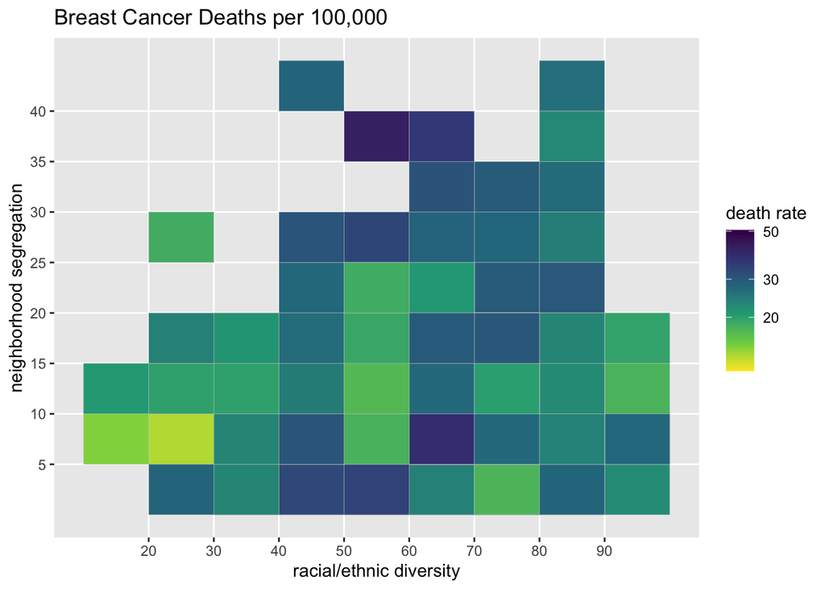

```r
p <- dat %>% ggplot(aes(racial_ethnic_diversity_total_population,
                          neighborhood_racial_ethnic_segregation_total_population,
                        fill = breast_cancer_deaths_total_population)) +
        geom_tile(color = "grey80") +
        scale_x_binned(n.breaks = 10) +
        scale_y_binned(n.breaks = 10)  +
        scale_fill_viridis_c(trans="log10", name = "death rate", direction = -1 ) +
        #theme(axis.text.y = element_text(angle = 30, size = 6)) +
        ggtitle("Breast Cancer Deaths per 100,000") +
        ylab("neighborhood segregation") +
        xlab("racial/ethnic diversity")

print(p)
```

There are clear racial disparities in the rates of breast cancer deaths across the US cities, with Blacks experiencing much higher rates of breast cancer deaths than all other racial groups.

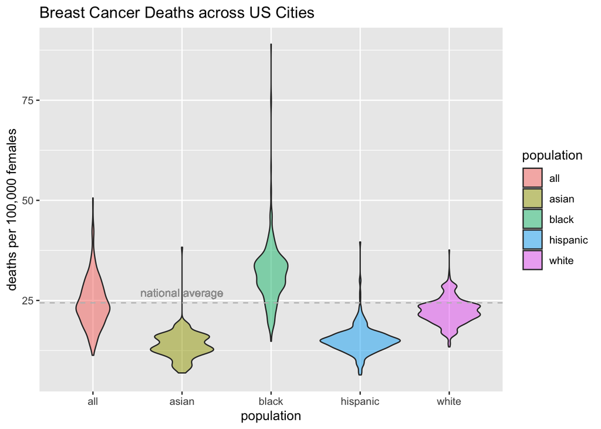

```r
dat %>%    pivot_longer(cols = starts_with('breast_cancer_deaths'),
                        names_to = "population", values_to = "deaths") %>%
             mutate(population = str_replace(population, "breast_cancer_deaths_", "")) %>%
             mutate(population = str_replace(population, "total_population", "all")) %>%
             ggplot() +
             geom_violin(aes(population, deaths, fill = population), alpha = 0.5) +
             geom_hline(yintercept= 24.4, lty = 2, col = 'grey') +
             geom_text(label = "national average", x = "asian", y= 27, hjust = "center",
                       col = 8, size = 3.3) +
             ylab("deaths per 100,000 females") +
             ggtitle("Breast Cancer Deaths across US Cities")
```

The presence of additional mammography sites per 100,000 people does not reduce mortality in highly segregated neighborhoods; in fact mortality is highest in areas with some of the highest number of sites (7.5 -10 per 100K) and highest levels of segregation. However, in areas where there are numerous sites accessible and the neighborhood segregation score is low, breast cancer mortality rates are the lowest. You can also see that an increase in the number of mammography sites is only advantageous for Black females in neighborhoods where the segregation score is low (less than the national average of 10.9).

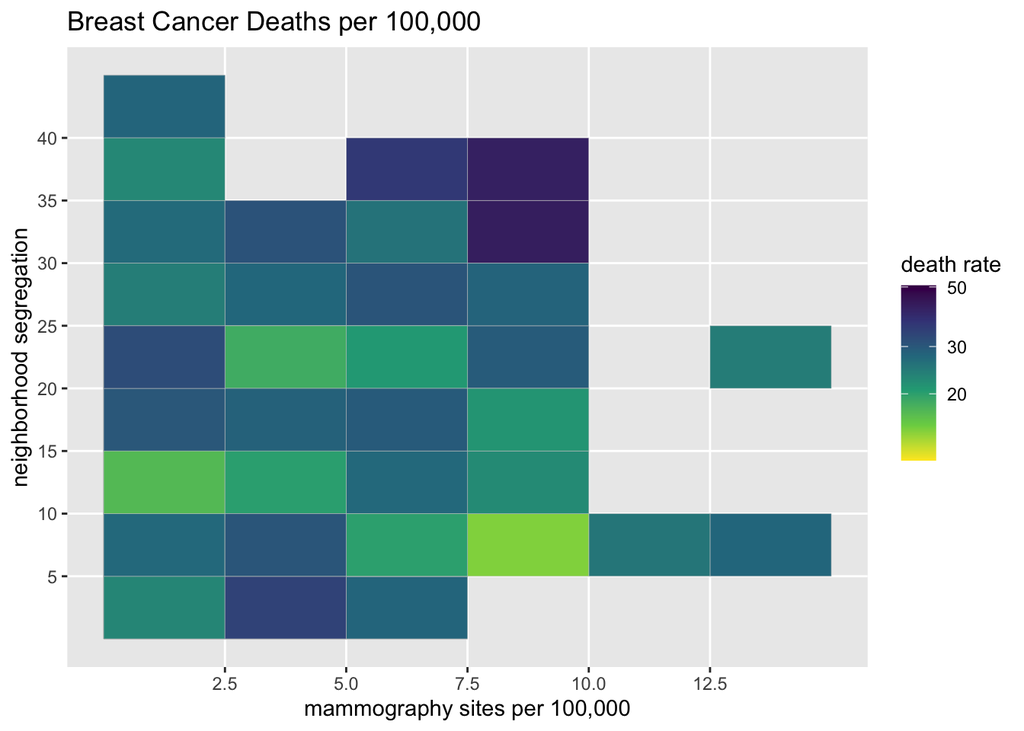

```r
p <- dat %>% ggplot(aes(sites_per_100K,
                          neighborhood_racial_ethnic_segregation_total_population,
                        fill = breast_cancer_deaths_total_population)) +
        geom_tile(color = "grey80") +
        scale_x_binned(n.breaks = 5) +
        scale_y_binned(n.breaks = 10)  +
        scale_fill_viridis_c(trans = "log10",
                             name = "death rate", direction = -1) +
        #theme(axis.text.y = element_text(angle = 30, size = 6)) +
        ggtitle("Breast Cancer Deaths per 100,000") +
        ylab("neighborhood segregation") +
        xlab("mammography sites per 100,000")

print(p)
```

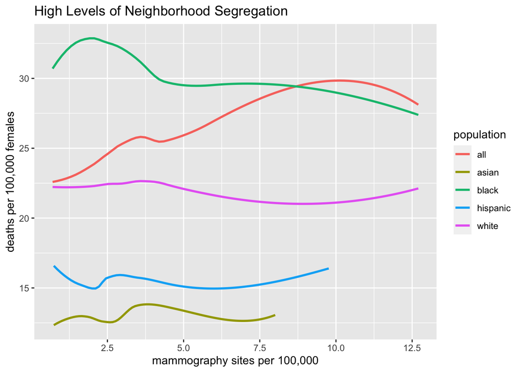

```r
cols = names(dat)[names(dat) %>% str_detect('breast_cancer_deaths')]

p1 <- dat %>% filter(neighborhood_racial_ethnic_segregation_total_population >= 10.9) %>%
        select(append(cols, 'sites_per_100K')) %>%
        gather("population", "deaths", -sites_per_100K) %>%
        mutate(population = str_replace(population, "breast_cancer_deaths_", "")) %>%
        mutate(population = str_replace(population, "total_population", "all")) %>%
        ggplot() +
        geom_smooth(aes(sites_per_100K, deaths, col = population), se = FALSE) +
        xlab('mammography sites per 100,000') +
        ylab('deaths per 100,000 females') +
        ggtitle('High Levels of Neighborhood Segregation')


p2 <- dat %>% filter(neighborhood_racial_ethnic_segregation_total_population < 10.9) %>%
        select(append(cols, 'sites_per_100K')) %>%
        gather("population", "deaths", -sites_per_100K) %>%
        mutate(population = str_replace(population, "breast_cancer_deaths_", "")) %>%
        mutate(population = str_replace(population, "total_population", "all")) %>%
        ggplot() +
        geom_smooth(aes(sites_per_100K, deaths, col = population), se = FALSE) +
        xlab('mammography sites per 100,000') +
        ylab('deaths per 100,000 females') +
        ggtitle('Low Levels of Neighborhood Segregation')


print(p1)
```

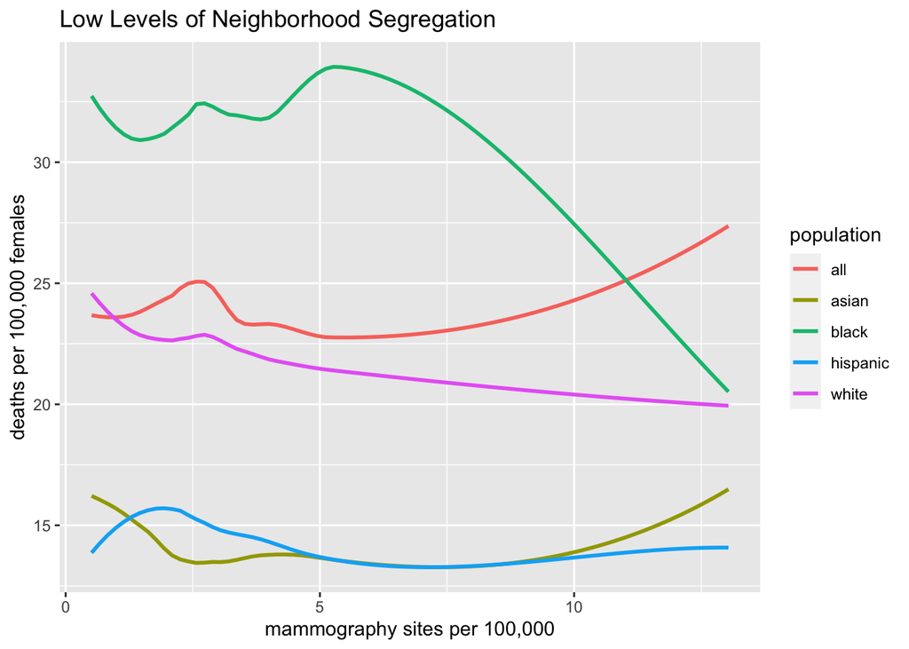

```r
print(p2)
```

*Exploratory Analysis for Shiny App:*

Other health factors/social determinants (data available with racial breakdown):

- breast_cancer_deaths
- high_school_completion
- limited_access_to_healthy_foods
- unemployment_annual_neighborhood_level
- uninsured
- prenatal_care
- teen_births
- low_birthweight

Data Prep

```r
# identify all metrics available w/ racial breakdown in data frame
race_vars <- names(dat)[names(dat) %>% str_detect("asian")] %>% str_replace("asian", "")
# identify specific col names that contain race metric
temp <- names(dat)[names(dat) %>% str_detect(str_c(race_vars, collapse="|"))]
# filter out age/gender cols since some metrics available at race, as well as gender/age breakdown
race_cols <- temp[temp %>% str_detect("age|female|male", negate = TRUE)]  # final list of race related metric col names

race_dat <- dat %>% select(append(append(race_cols,  "city_name"), "state_abbr")) %>%
            pivot_longer(!c(city_name, state_abbr),
                         names_to = "measure", values_to = "estimate") %>%
            mutate(measure = str_replace(measure, "total_population", "all")) %>%
            mutate(measure = stri_replace_last_fixed(measure, '_', " ")) %>%
            separate(measure, c("measure", "population"), sep = " ")
```

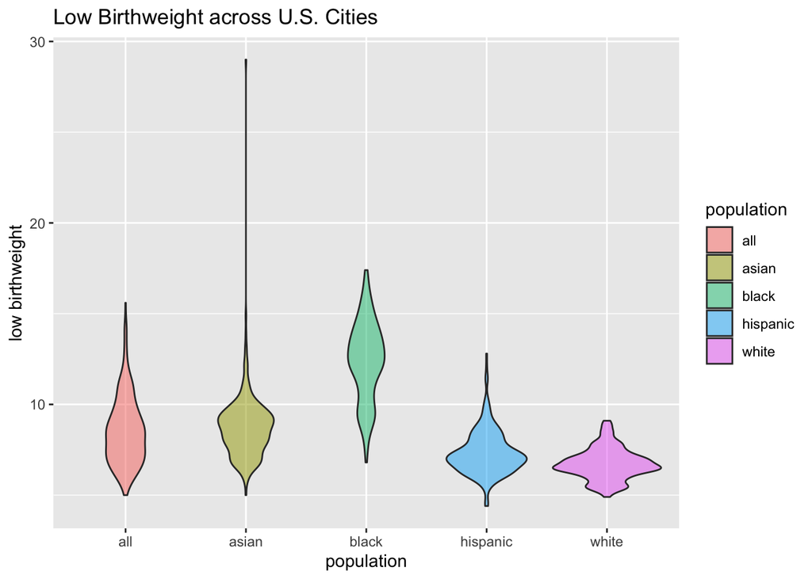

```r
factor = "low_birthweight" # select from list above (race_vars) [user input in shiny app]

factor_label  = str_replace_all(factor, "_", " ")
race_dat %>% filter(measure == factor) %>%  ggplot() +
             geom_violin(aes(population, estimate, fill = population), alpha = 0.5)  +
             ylab(factor_label) +
             ggtitle(paste(str_to_title(factor_label),
                           "across U.S. Cities"))
```

Compare factor against breast cancer mortality

```
## Note: Using an external vector in selections is ambiguous.
## ℹ Use `all_of(factor)` instead of `factor` to silence this message.
## ℹ See <https://tidyselect.r-lib.org/reference/faq-external-vector.html>.
```

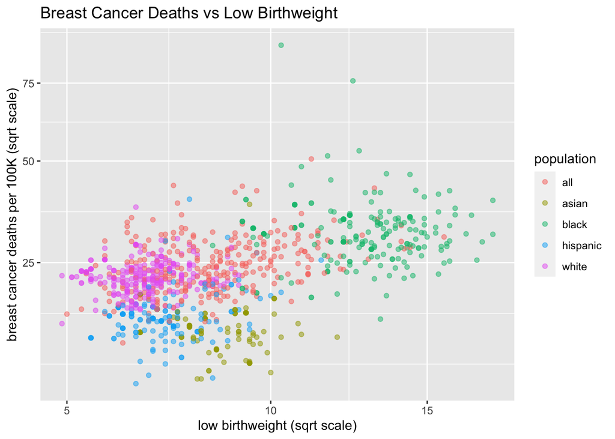

```r
race_dat %>%  pivot_wider(id_cols = c(state_abbr, city_name, population),
                       names_from = measure,
                       values_from = estimate
                       ) %>%
  select(c("population", factor, "breast_cancer_deaths")) %>% drop_na() %>%
  ggplot() +
  geom_point(aes_string(x= factor,
                        y="breast_cancer_deaths",
                        fill = "population",
                        col = "population"), alpha = .5)  +
  scale_y_sqrt() +
  scale_x_sqrt() +
  ylab("breast cancer deaths per 100K (sqrt scale)") +
  xlab(paste(factor_label, '(sqrt scale)')) +
  ggtitle(paste("Breast Cancer Deaths vs",
                str_to_title(factor_label))
          )
```